# Predicting How Well a Set of Exercises is Performed

Kiril Raytchev

16/07/2017

## Summary

The goal of this report is to predict the manner in which a set of exercises is performed. This is the “classe” variable in the provided data set. The process of variables selection to predict with is also provided.  
The following topics are discussed:

- how the model is built;
- how cross validation is used;
- the expected out of sample error;
- substantiation of the choices made.

## Setting up data analyses program environment

To ensure reproducibility we set the seed:

```r
set.seed(11245)
```

The following libraries are loaded:

```r
library(tidyverse)
library(caret)
library(mlbench)
library(parallel)
library(doParallel)
library(rattle)
library(broom)
```

In order to provide parallel processing for the calculations we dedicate one core for the OS and the rest for the data analyses program environment.

```r
cluster <- makeCluster(detectCores() - 1) # convention to leave 1 core for OS
registerDoParallel(cluster)
```

## Data import and variable selection

First we read training data set and convert `classe` variable to factor variable:

```r
data <- read_csv("pml-training.csv", col_types = cols(
        classe = col_factor(levels = c("A", "B", "C", "D", "E"))
))
```

```r
obs <- nrow(data)
NAsFillRate <- 0.5
is_NAsFillRate <- function(x){
        sum(is.na(x))/obs < NAsFillRate
}
training <- data %>%
        select_if(is_NAsFillRate) %>%
        select(8:60) %>%
        filter(!is.na(magnet_forearm_y))
```

We get a training set with 19621 observations of 53 variables.

## Model building

We choose to use *k-fold* cross-validation with number of *folds = 10* and random forest method:

```r
fitControl <- trainControl(method = "cv",
                           number = 10,
                           allowParallel = TRUE)

rfFit <- train(x = training[ , -53],
               y = training$classe,
               method = "rf",
               data = training,
               trControl = fitControl)

stopCluster(cluster)
registerDoSEQ()
```

We get the following results:

```r
rfFit
```

```
## Random Forest
##
## 19621 samples
##    52 predictor
##     5 classes: 'A', 'B', 'C', 'D', 'E'
##
## No pre-processing
## Resampling: Cross-Validated (10 fold)
## Summary of sample sizes: 17659, 17658, 17657, 17658, 17660, 17659, ...
## Resampling results across tuning parameters:
##
##   mtry  Accuracy   Kappa
##    2    0.9952096  0.9939401
##   27    0.9954134  0.9941982
##   52    0.9902660  0.9876866
##
## Accuracy was used to select the optimal model using  the largest value.
## The final value used for the model was mtry = 27.
```

```r
rfFit$resample
```

```
##     Accuracy     Kappa Resample
## 1  0.9943963 0.9929122   Fold02
## 2  0.9928644 0.9909748   Fold01
## 3  0.9938869 0.9922673   Fold04
## 4  0.9938900 0.9922705   Fold03
## 5  0.9984709 0.9980660   Fold06
## 6  0.9964304 0.9954845   Fold05
## 7  0.9928644 0.9909739   Fold08
## 8  0.9979613 0.9974212   Fold07
## 9  0.9948980 0.9935455   Fold10
## 10 0.9984709 0.9980657   Fold09
```

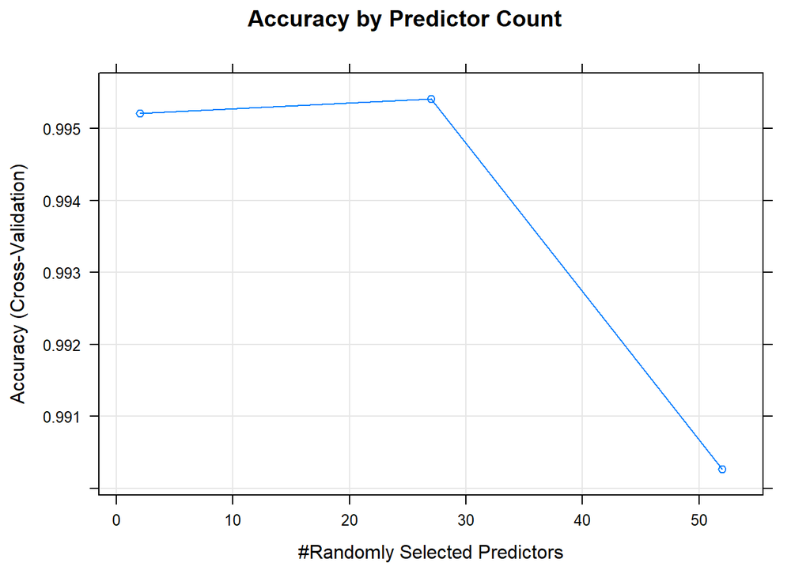

```r
plot(rfFit, main = "Accuracy by Predictor Count")
```

```r
confusionMatrix.train(rfFit)
```

```
## Cross-Validated (10 fold) Confusion Matrix
##
## (entries are percentual average cell counts across resamples)
##
##           Reference
## Prediction    A    B    C    D    E
##          A 28.4  0.1  0.0  0.0  0.0
##          B  0.0 19.2  0.1  0.0  0.0
##          C  0.0  0.0 17.3  0.1  0.0
##          D  0.0  0.0  0.0 16.3  0.0
##          E  0.0  0.0  0.0  0.0 18.3
##
##  Accuracy (average) : 0.9954
```

Variable importance is seen on the following figure:

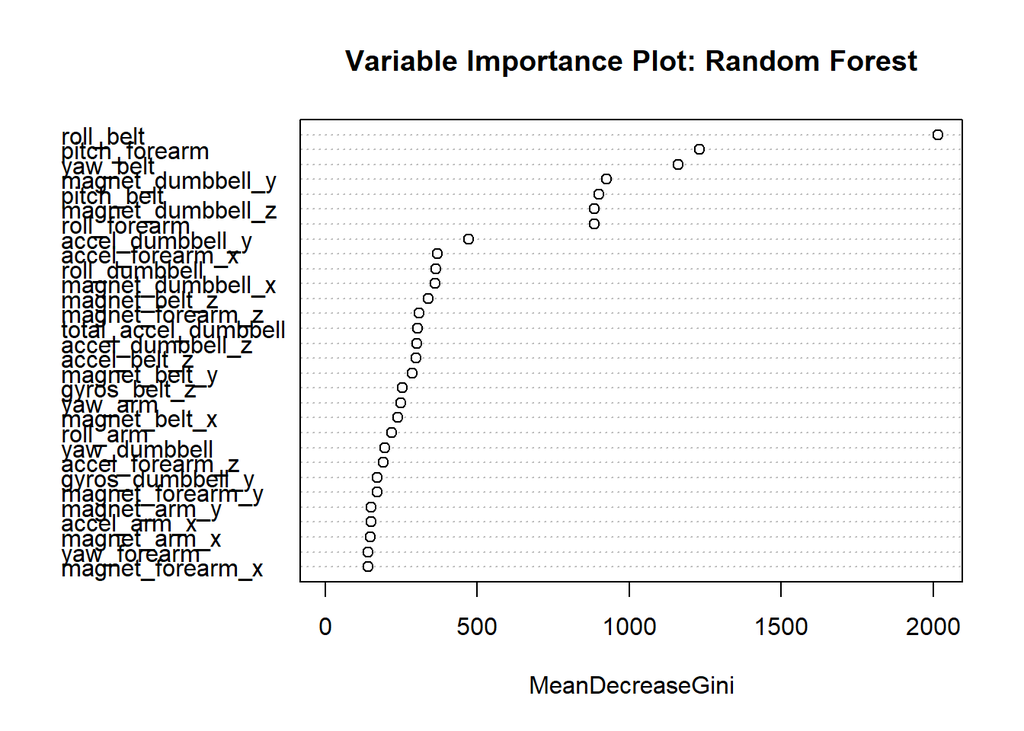

```r
varImpPlot(rfFit$finalModel, main = "Variable Importance Plot: Random Forest")
```

The expected error is *0.46%* as seen from the *out-of-bag* error estimation:

```r
rfFit$finalModel
```

```
##
## Call:
##  randomForest(x = x, y = y, mtry = param$mtry, data = ..1)
##                Type of random forest: classification
##                      Number of trees: 500
## No. of variables tried at each split: 27
##
##         OOB estimate of  error rate: 0.46%
## Confusion matrix:
##      A    B    C    D    E  class.error
## A 5575    3    1    0    0 0.0007169744
## B   21 3773    3    0    0 0.0063207796
## C    0   11 3399   12    0 0.0067212157
## D    0    1   25 3187    3 0.0090174129
## E    0    1    5    5 3596 0.0030496257
```

### Conclusion

The model is good to go for validation on the test data set.